# Adding R to your A_senal

John Pertell

May 19, 2017

## Introduction

A Beginners Look At R

John Pertell

Database Administrator for Dialysis Clinics Inc.

Email: jpertell@gmail.com  
Twitter: @jayape  
Blog: http://www.pertell.com/sqlservings

## Who I Am

- Working for DCI since 2000
- Started working on Access reports
- Became Senior DBA in 2006

## Who I Am…Not

**I am not an “R”tist**

## Agenda

- A little R background
- Working in R
  - Basic syntax
  - Functions
  - Adding and working with packages
  - Working with data - getting, shaping
  - R application (Markdown, Shiny, Notebooks)

## Agenda (If there’s time)

- R and SQL 2016
- What it is
- Installing and configuring
- Using R and SQL 2016

## (Not on the) Agenda

> - Math and Statistics
> - Well, maybe a little…

## A Little R Background

- Open source language used for working with data (statistics, analysis, visualization)
- One of the fastest growing, most popular languages for data scientists
- Connects to many data sources
- Runs on multiple platforms
- Available from the CRAN repository
- Constantly growing

## An R Visualization

[figure not shown]

```r
knitr::include_graphics("images/xkcd1.png")
```

http://xkcd.com/1281

## Basic atomic class of objects

- Character
- Numeric
- Integer
- Logical (TRUE or FALSE)

## Most basic object is a vector

- One dimensional
- Can have more than one value
- Can only contain objects of the same class (character, etc)
- (But you can create a list with different classes)

## Other object types:

- Matrix - vectors with dimensions
- Each element must be the same object class
- Factors - represent categorical data
- Useful for modeling data
- Use labels (“Yes”, “No”) instead of integers (1, 2)
- Data Frames - stores tabular data
- Observations and variables instead of rows and columns
- Can store different object classes in separate variables

## Some things to remember

- R is case sensitive
- A variable called *A* is not the same as one called *a*
- You can use single (’) or double (“) quotes for characters
- But you should be consistent in your code
- You can use less than minus sign (<-) or equals (=) for assigning values
- Again, be consistent
- <- is preferred

## Packages

- Packages extend R by adding functions
- Install through IDE or in script/console
- Can be installed from a .zip file if you’re not connected to the internet
- Load a package for your code before using it
- Some popular packages:
- ggplot2 - plots
- dplyr - manipulating data
- RODBC - connect to a ODBC data source

## An R Cheatsheet

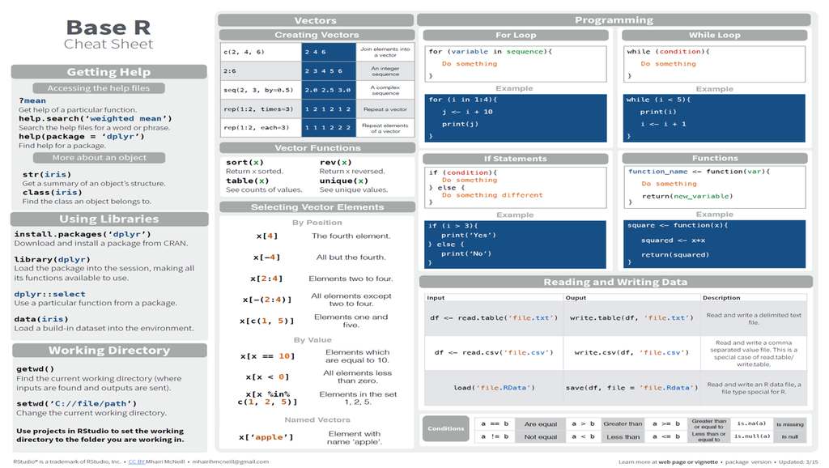

```r
knitr::include_graphics("images/cheatsheet1.png")
```

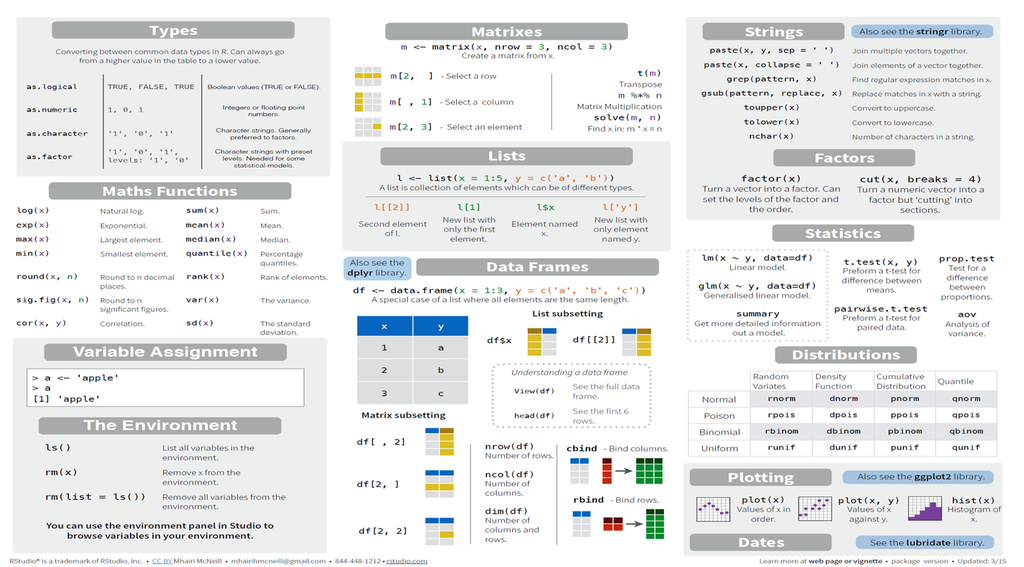

```r
knitr::include_graphics("images/cheatsheet2.png")
```

# R Demo Time

## Basic Math

| Sign | Operation |
| --- | --- |
| + | Addition |
| - | Subtraction |
| * | Multiplication |
| / | Division |
| ^ or ** | Exponential |
| %% | Modulus |
| %/% | Integer Division |

```
1 + 3
```

```
## [1] 4
```

```
6 - 5
```

```
## [1] 1
```

```
5 * 5
```

```
## [1] 25
```

```
4 / 2
```

```
## [1] 2
```